[figure not shown]

```python
import numpy as np
import pandas as pd
import plotly.express as px
import plotly.graph_objects as go
import matplotlib.pyplot as plt
from matplotlib import cm
from matplotlib.ticker import LinearLocator, FormatStrFormatter
%matplotlib inline
```

# Seminario: Optimización con Pyomo

*Jose Angel Velasco (javelascor@indra.es)*

*Indra Digital Labs | IA*

*26 Marzo de 2021*

## Motivación

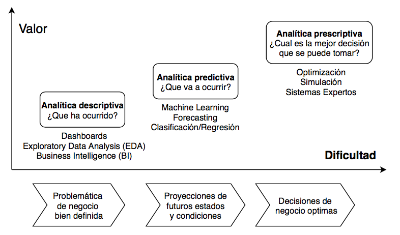

## Introducción a la optimizacion

- La **optimización** consiste en la toma de la mejor decisión posible (de un conjunto de soluciones factibles) en base a un objetivo concreto (funcion objetivo) y sujeto a ciertos requisitos (restricciones)
- Mediante **programación matemática** se puede formular dicha funcion objetivo y restricciones utilizando un lenguaje algebraico
- Alternativa a programación matemática: *métodos heuristicos*
- El soporte a la toma de decisiones mediante optimización con programación matemática es a menudo desconocida o bien descartada por falta de tiempo y/o recursos.
- En este seminario se realizará un breve repaso a conceptos de optimización y se presentará Pyomo para la resolución de diferentes problemas tipo.

##### Ejemplos

- Problemas Lineales
  - **Problemas del transporte**
  - Problema de la planificación de la producción
  - Problema de la dieta
  - **Problema del flujo en una red**
  - **Problema de la cartera de valores**
  - Problema del despacho economico de centrales eléctricas
- Problemas lineal entero-mixto
  - **Optimización de rutas**
  - Problema de la mochila
  - Problema de Identificación de sintomas relevantes
  - Problema de la academia de ingenieria
  - Problema del horario
  - **Problema de localización de plantas logisticas**
  - **Problema de programación de centrales eletricas (térmica)**
  - Problema de coordinación de centrales electricas (termica e hidrotérmica)
- Problemas no-lineales
  - **Problema de estimación de estado de sensores (state estimation)**
  - Problema del reparto óptimo de carga en redes electricas (Optimal power flow)
  - **Problema de la asignación de trafico**
  - Problemas de regresión (mínimos cuadrados)
  - Aplicaciones de inteligencia artificial (ej: redes neuronales RMSE como objetivo)
  - Control óptimo para el alcance de un blanco

### Programacion matematica

- La programación matemática tiene su origen en 1947 cuando George B. Dantzig publicó el algoritmo [Simplex](https://en.wikipedia.org/wiki/Simplex_algorithm) (Programación lineal)

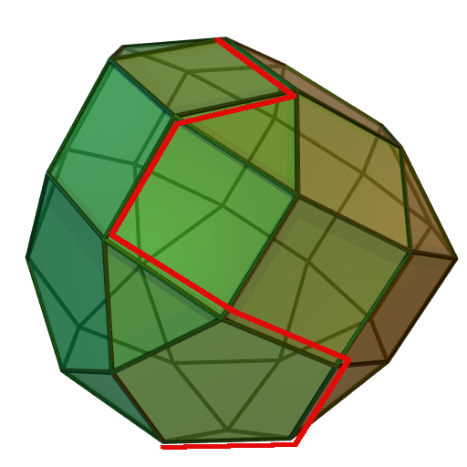

- En la páctica, un problema de optimización consiste minimizar (o maximizar) una función objetivo **convexa** y real $f(x)$ eligiendo sistemáticamente valores de entrada (tomados de un conjunto permitido) y calculando el valor de la función sujeto a ciertas restricciones de igualdad y desigualdad.

\begin{array}{ll} \min & f(x) = c^{T} x\\ s.t. & g(x) = b\\ & h(x) \leq c\\ & x \geq 0 \end{array}

- $x$ es la variable de decision
- $f(x)$ es la funcion objetivo (minimizar costes, retrasos, riesgos, etc...)
- $g(x)$ y $h(x)$ son restricciones y definen limitaciones, realidades de negocio, etc.

### Forma standard

- minimizacion
- restricciones de igualdad ( si las hay, existen tecnicas para convertir a igualdad)
- $x>0$
- $b>0$
  - Si la función objetivo o las restricciones tienen elementos no lineales ($x^2, sin(x), ...$), el problema es NLP (Non-Linear Programming)
- Si existen variables enteras $x \in (0,1)$ el problema es MIP (Mixed-Integer Programming)
- Una solución $\tilde{x} = (x_1 , x_2 , \ldots , x_n )$ que satisface todas las restricciones se denomina *solucion factible*. El conjunto de todas esas soluciones es la *region de factibilidad*
- Un punto factible $\tilde{x}^{*}$ tal que $f(\tilde{x}^{*}) \leq f(\tilde{x})$ para cualquier otro punto factible $\tilde{x}$ se denomina una *solucion optima* del problema.

### Dualidad

Es una relacion simetrica, esto es, si el problema D es el dual del problema P, entonces P es el dual de D.

Dado el problema de programacion lineal denominado problema *primal*,

\begin{array}{ll} \min & f(x) = c^{T} x\\ s.t. & Ax \ge b\\ & x \geq 0 \end{array}

su problema *dual* es maximizar:

\begin{array}{ll} \max & f^{'}(y) = b^{T} y\\ s.t. & A^{T} y \leq c\\ & y \geq 0 \end{array}

$y$ es **variable dual**

Bajo ciertas hipotesis, los problemas *primal* y *dual* dan lugar al mismo valor optimo de la funcion objetivo, y por tanto se puede resolver indirectamente el problema primal resolviendo el problema dual.

### Programacion Lineal

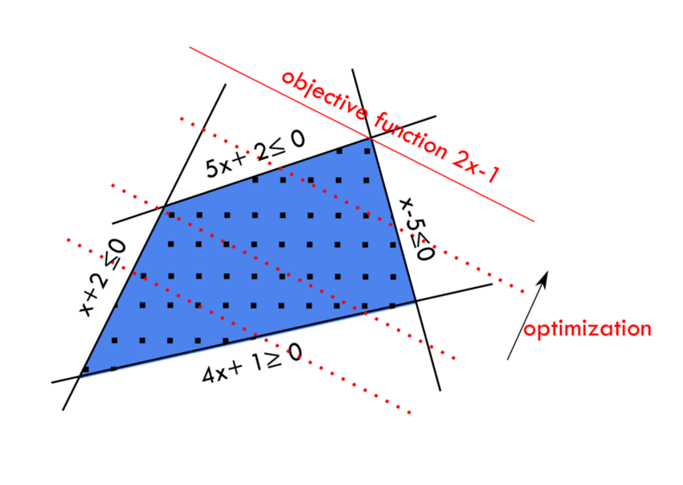

- Funcion objetivo y restricciones lineales
- Algoritmo:
  - simplex
  - Punto interior
- Ejemplo:

\begin{array}{ll} \min & 2x + 3y \\ s.t. & 3x + 4y \geq 1\\ & x,y \geq 0 \end{array}

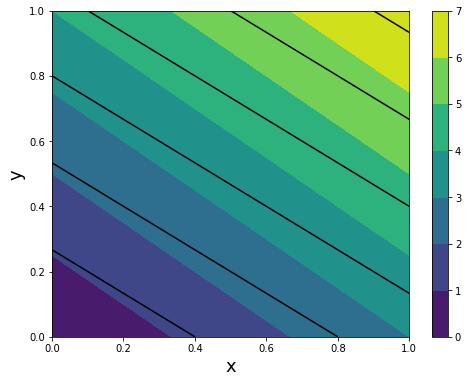

```python
x = np.linspace(0, 1)
y = np.linspace(0, 1)
xx, yy = np.meshgrid(x, y)

plt.figure(figsize=(8,6))
plt.contour(xx, yy, 2 * xx + 3 * yy, colors='k')
plt.contourf(xx, yy, 3 * xx + 4 * yy, cmap=plt.cm.viridis)
plt.colorbar()
plt.xlabel('x', fontsize=18)
plt.ylabel('y',fontsize=18)
plt.show()
```

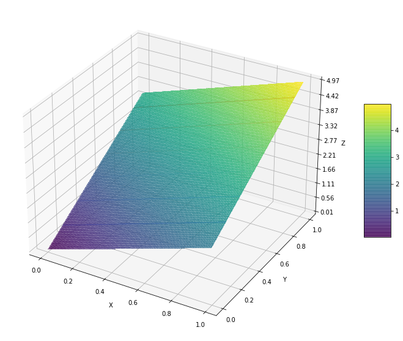

```python
#we will use numpy functions in order to work with numpy arrays
def function(x,y):
    z  = 2 * x + 3 * y
    #z  = 3 * x + 4 * y
    return z

n = 200
x = np.random.uniform(0, 1, n)
y = np.random.uniform(0, 1, n)
z = function(x, y)

#we create two 1D arrays of the desired lengths:
x_1d = np.linspace(min(x), max(x), n)
y_1d = np.linspace(min(y), max(y), n)

#And we use the meshgrid function to create the X and Y matrices!
X, Y = np.meshgrid(x_1d, y_1d)

#Using Numpy arrays, calculating the function value at the points is easy!
Z = function(X,Y)

fig = plt.figure(figsize=(16,10))
ax = fig.add_subplot(111, projection='3d')

surf = ax.plot_surface(X, Y, Z,
                       rstride=2,
                       cstride=2,
                       alpha=0.6,
                       cmap=plt.cm.viridis, #cm.jet, # coolwarm
                       linewidth=0, antialiased=False)
# Customize the z axis.
#ax.set_zlim(-120, 120)
ax.zaxis.set_major_locator(LinearLocator(10))
ax.zaxis.set_major_formatter(FormatStrFormatter('%.02f'))

# add contour
cset = ax.contour(X, Y, Z, zdir='y', cmap=cm.coolwarm)

ax.set_xlabel('X')
#ax.set_xlim(-8, 8)
ax.set_ylabel('Y')
#ax.set_ylim(-8, 8)
ax.set_zlabel('Z')
#ax.set_zlim(-2, 2)

# Add a color bar which maps values to colors.
fig.colorbar(surf, shrink=0.4, aspect=5)
plt.show()
```

### Programación Lineal Entera-Mixta (MILP)

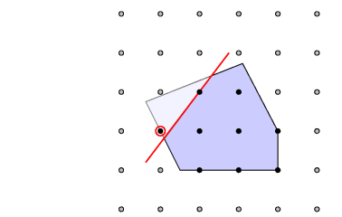

- Funcion objetivo y restricciones lineales
- Incluye toma de decisiones logicas con variables binarias
- Algoritmos:
  - Ramificación y acotamiento (branch & bound)
  - Cortes de gomory
- Ejemplo: Seleción de la mejor ruta de producción

\begin{array}{ll} \min & c^T + d^Ty \\ s.t. & Ax + By \leq 1\\ & x \geq 0 \\ & y \in (0,1) \end{array}

### Programación No-Lineal (NLP)

- Funcion objetivo y/o restricciones no-lineales
- Algoritmos:
  - Condiciones de optimalidad de Karush-Kuhn-Tucker
- Ejemplo: Flujo de carga óptimo en red de energía eléctrica

\begin{array}{ll} \min & z = f(x) \\ s.t. & h(x)=0\\ & g(x)\le 0 \\ & x \le 0 \end{array}

- Ejemplo de funciones no lineales: Función de Rosenbrock

$$ f(x, y) = (a - x)^2 + b (y - x^2)^2 $$$$a=1$$$$b=100$$

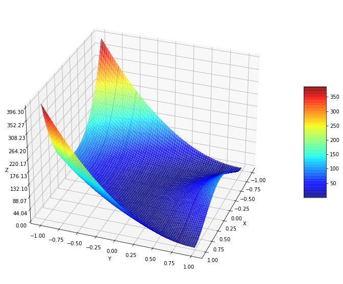

```python
#we will use numpy functions in order to work with numpy arrays
def rosembrock(x,y):
    z  = (1-x)**2+100*(y-x**2)**2
    return z

n = 150
x = np.random.uniform(-1, 1, n)
y = np.random.uniform(-1, 1, n)
z = rosembrock(x, y)

#we create two 1D arrays of the desired lengths:
x_1d = np.linspace(min(x), max(x), n)
y_1d = np.linspace(min(y), max(y), n)

#And we use the meshgrid function to create the X and Y matrices!
X, Y = np.meshgrid(x_1d, y_1d)

#Using Numpy arrays, calculating the function value at the points is easy!
Z = rosembrock(X,Y)

fig = plt.figure(figsize=(16,10))
ax = fig.add_subplot(111, projection='3d')

surf = ax.plot_surface(X, Y, Z,
                       rstride=2,
                       cstride=2,
                       alpha=0.6,
                       cmap=cm.jet,
                       linewidth=0,
                       antialiased=False)
# Customize the z axis.
#ax.set_zlim(-120, 120)
ax.zaxis.set_major_locator(LinearLocator(10))
ax.zaxis.set_major_formatter(FormatStrFormatter('%.02f'))

# add contour
cset = ax.contour(X, Y, Z, zdir='y', cmap=cm.coolwarm)

ax.set_xlabel('X')
#ax.set_xlim(-8, 8)
ax.set_ylabel('Y')
#ax.set_ylim(-8, 8)
ax.set_zlabel('Z')
#ax.set_zlim(-2, 2)

ax.view_init(30, 20)

# Add a color bar which maps values to colors.
fig.colorbar(surf, shrink=0.4, aspect=5)
plt.show()
```

### Programación No Lineal Entero Mixta (MINLP)

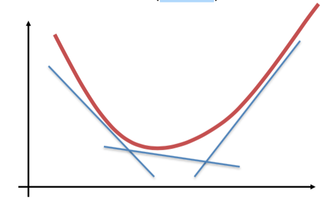

- Funcion objetivo y/o restricciones no-lineales
- Incluye toma de decisiones logicas con variables binarias
- Algoritmos:
  - Aproximaciones Exteriores
- Ejemplo: Planificación de la expansión de la red eléctrica

\begin{array}{ll} \min & z = f(x) + d^T y \\ s.t. & h(x) + By=0\\ & g(x) + Dy \le 0 \\ & x \le 0 \\ & y \in (0,1) \end{array}

# Pyomo

- Dos de los lenguajes de modelado comerciales más utilizados para resolver este tipo de problemas matemáticos son [GAMS](https://www.gams.com) y [AMPL](https://ampl.com).
- Como alternativa libre y gratuita existe Pyomo que es un lenguaje de modelado algebraico basado en **Python**
- Otras alternativas: [JuMP (julia)](https://jump.dev), **SciPy**, **CVXopt**, **PuLP**
- Pyomo es un un lenguaje de modelado algebraico compatible con una amplia gama de tipos de problemas de optimización tipo:
  - [LP](https://www.analyticsvidhya.com/blog/2017/02/lintroductory-guide-on-linear-programming-explained-in-simple-english/) (Linear Prograaming)
  - [NLP](https://en.wikipedia.org/wiki/Nonlinear_programming) (Non-Linear Programming)
  - [MIP](https://en.wikipedia.org/wiki/Integer_programming) (Mixed-Integer Programming)
  - [MINLP](https://neos-guide.org/content/mixed-integer-nonlinear-programming) (Mixed-Integer Non-Linear Programming)
- Deseable optimización convexa
- Pyomo se comunica con los principales solvers comerciales, gratuitos y/o libres:
  - [GLPK (GNU Linear Programming Kit)](https://www.gnu.org/software/glpk/) (libre, LP/MIP)
  - [IPOPT](https://coin-or.github.io/Ipopt/) (libre, LP/NLP)
  - [CONOPT](http://www.conopt.com) (gratuito, NLP)
  - [CPLEX](https://www.ibm.com/es-es/analytics/cplex-optimizer) (comercial, LP/MIP)
  - [GUROBI](https://www.gurobi.com/products/gurobi-optimizer/) (comercial, LP/MIP)
  - [BARON (Branch-and-Reduce Optimization Navigator)](https://minlp.com/baron) (comercial MIP/MINLP)
  - [CBC (Coin-or branch and cut)](https://projects.coin-or.org/Cbc)(libre, MIP)
  - [MindtPy (Mixed-Integer Nonlinear Decomposition Toolbox in Pyomo)](https://pyomo.readthedocs.io/en/stable/contributed_packages/mindtpy.html) (libre, MINLP)

| Solver | LP | MIP | NLP | MINLP |
| --- | --- | --- | --- | --- |
| GLPK | X | X | - | - |
| IPOPT | - | - | X | - |
| CONOPT | - | - | X | - |
| CBC | - | X | - | - |
| BARON | - | X | X | X |
| GUROBI | X | X | - | - |
| CPLEX | X | X | - | - |
| MindtPy | - | - | - | X |

## Instalación

Crear entorno de python con version 3.6 o 3.7 con una ventana de comandos

```
conda create -n pyomo36 python=3.6 numpy pandas matplotlib plotly scipy jupyter ipython
```

Comprobar entorno

```
conda env list
```

Activar entorno

```
conda activate pyomo36
```

Instalar pyomo

```
conda install pyomo -c conda-forge
```

Comprobar que se ha instalado correctamente

```
pyomo
```

Instalar extras: [NEOS server](https://neos-server.org/neos/)

```
conda install pyomo.extras --channel conda-forge
```

Instalar solver GLPK

```
conda install glpk -c conda-forge
```

Instalar solvers IPOPT

```
conda install -c cachemeorg ipopt_bin
```

Detectar solvers instalados

```
pyomo help -s
```

Ayuda sobre componentes

```
pyomo help --components
```

Ayuda sobre pyomo en general

```
pyomo help -a
```

## Modelado

- El modelado es un proceso fundamental en muchos aspectos de la investigación, ingeniería y los negocios. El modelado involucra la formulación de una representación simplificada de una sistema o de un objecto del mundo real.
- Un modelo matemático incluye los siquientes componentes:
  - **Variables**: Representan incognitas dentro del modelo y el objetivo es determinar su valor. Los valores que toman las variables corresponden con la solución del problema y proporcionan la decisión a tomar óptima ya que son el resultado de un proceso de optimización.
  - **Parámetros**: Representan los datos conocidos sobre el problema de optimización. Pueden ser vectores o matrices.
  - **Función objectivo**: Ecuación a minimizar o maximizar que relaciona las variables con los parámetros del modelo.
  - **Restricciones**: Ecuaciones de igualdad o desigualdad que imponen ciertos comportamientos a las variables.

## Proceso

- Pyomo soporta un diseño orientado a objectos para la modelización. Los pasos a seguir son los siguientes
  - Definir modelo y componentes
  - Instanciar modelo
  - Aplicar solver
  - Consultar resultados

## Componentes

Un modelo de pyomo consiste en un conjunto de componentes de lenguaje algebraico definidos a traves de clases de pyomo:

- Indices
- conjuntos
- variables de decisión
- parámetros
- función objetivo
- restricciones.
- expresiones

## Tipos de modelos

### Concreto

- Paramteros del modelo directos

\begin{array}{ll} \min & z= 2x_1 + 3x_2\\ s.t. & 3x_1 + 4x_2 \geq 1\\ & x_1,x_2 \geq 0 \end{array}

### Abstracto

- Parámetros del modelo
- Independecia modelo y datos

\begin{array}{lll} \min & z= \sum_{j=1}^n c_j x_j & \\ s.t. & \sum_{j=1}^n a_{i,j} \cdot x_j \geq b_i & \forall i = 1 \ldots m\\ & x_j \geq 0 & \forall j = 1 \ldots n \end{array}

## Ejemplo Modelo Abstracto: Problema del transporte

- Original problem formulation:
  - Dantzig, G B, Chapter 3.3. In Linear Programming and Extensions. Princeton University Press, Princeton, New Jersey, 1963.

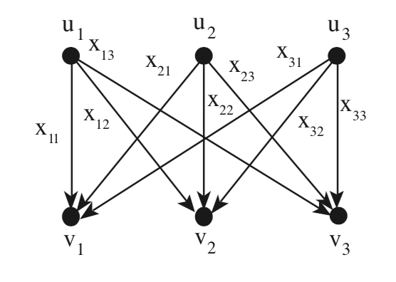

\begin{equation} \begin{array}{lll} \min & z = \sum_{j=1}^n c_{i,j} x_{i,j} & (1a) & \\ s.t. & \sum_{j=1}^n x_{i,j} \leq u_i & ,\forall i \in (1, \ldots, m) & (1b) \\ & \sum_{i=1}^m x_{i,j} = d_j & ,\forall i \in (1, \ldots, n)& (1c) \\ & x_{i,j} \geq 0 & ,\forall j \in (1 ,\ldots, n) & (1d) \end{array} \end{equation}

**Datos**

- $m$ Numero de origenes
- $n$ Numero de destinos
- $u_i$ Stock de producto en origen $i$
- $d_j$ Demanda de producto en destino $j$
- $c_{i,j}$ coste unitario de envio de producto desde origen $i$ a destino $j$ (€/ud)

**Variable objetivo (o de decisión)**

- $x_{i,j}$ Cantidad de producto que va del origen $i$ al destino $j$

**Restricciónes**

- **1b**: Limitación stock
- **1c**: garantizar suministro demanda
- **1d**: Cantidades positivas. *Esto implica que la direccion de envıo del producto esta prefijada desde los distintos orıgenes hasta los destinos. No obstante, otras hipotesis podrıan tenerse en cuenta. Por ejemplo, podrıa no limitarse el signo de las variables , si no se quiere predeterminar cuales son los puntos de partida y llegada*

### importar libreria pyomo

```python
import pyomo.environ as pyo
```

### Iniciar modelo abstracto

```python
model = pyo.AbstractModel()
```

### Definir conjuntos (Sets) [opcion a]

```python
model.origen = pyo.Set() # origenes i in (1,...,m)
model.destino = pyo.Set() # destinos j in (1,...,n)
```

### Definir conjuntos (Sets) [opcion b]

```python
# Crear primero un parametro que marca la dimension del indice
model.m = pyo.Param(within='NonNegativeIntegers') # 'PositiveReals' Si incluimos el 0
model.n = pyo.Param(within='NonNegativeIntegers')

# Definir luego los sets como un rango de valores entre 1 y la dimension del indice
model.I = pyo.RangeSet(1, model.m)
model.J = pyo.RangeSet(1, model.n)
```

### Definir parametros (datos conocidos)

```python
model.stock = pyo.Param(model.origen) # stock en origen i
model.demanda = pyo.Param(model.destino) # demanda en destino j
model.coste = pyo.Param(model.origen, model.destino) # coste de envio unitario de origen i a destino J
```

### definir variable de decision

```python
model.x = pyo.Var(model.origen, model.destino, domain=pyo.NonNegativeReals)
```

### Definir funcion objetivo

```python
### primero definir expresion que define la funcion objetivo
def pyomo_of(model):
    return sum(model.c[i,j] * model.x[i,j] for i in model.origen for j in model.destino)

### despues definir el component de la funcion objetivo
model.total_cost = pyo.Objective(rule=pyomo_of)
```

### Definir restricciones

```python
# Definir restriccion stock
def pyomo_constraint_stock(model, i):
    # devuelve la expression de la restriccion para el valor de i
    return sum(model.x[i,j] for j in model.destino) <= model.stock[i]

# definir entidad de la restriccion para indice I
model.const_stock = pyo.Constraint(model.origen, rule=pyomo_constraint_stock)
```

```python
# Definir restriccion demanda
def pyomo_constraint_demand(model, j):
    # devuelve la expression de la restriccion para el valor de i
    return sum(model.x[i,j] for i in model.origen) == model.demanda[j]

# definir entidad de la restriccion para indice I
model.const_demand = pyo.Constraint(model.destino, rule=pyomo_constraint_demand)
```

### Definir funcion que genera el modelo

```python
def dl_ia_opt_build_model():
    """ Builds an abstract pyomo model for the transport problem based
    :return: abstract pyomo model
    """

    import pyomo.environ as pyo

    model = pyo.AbstractModel()

    # Sets
    model.origen = pyo.Set() #  origenes (1,...,m)
    model.destino = pyo.Set() # destinos (1,...,n)

    # Parametros
    model.stock = pyo.Param(model.origen, domain=pyo.NonNegativeReals) # stock en origen i
    model.demanda = pyo.Param(model.destino, domain=pyo.NonNegativeReals) # demanda en destino j
    model.coste = pyo.Param(model.origen, model.destino, domain=pyo.NonNegativeReals) # coste de envio unitario de origen i a destino J

    # variable objetivo
    model.x = pyo.Var(model.origen, model.destino, domain=pyo.NonNegativeReals)

    ### primero definir expresion que define la funcion objetivo
    def of_expression(model):
        return sum(model.coste[i,j] * model.x[i,j] for i in model.origen for j in model.destino)

    ### despues definir el component de la funcion objetivo
    model.total_cost = pyo.Objective(rule=of_expression)

    # Definir restriccion stock
    def pyomo_constraint_stock(model, i):
        # devuelve la expression de la restriccion para el valor de i
        return sum(model.x[i,j] for j in model.destino) <= model.stock[i]

    # definir entidad de la restriccion para indice I
    model.const_stock = pyo.Constraint(model.origen, rule=pyomo_constraint_stock)

    # Definir restriccion demanda
    def pyomo_constraint_demand(model, j):
        # devuelve la expression de la restriccion para el valor de i
        return sum(model.x[i,j] for i in model.origen) == model.demanda[j]

    # definir entidad de la restriccion para indice I
    model.const_demand = pyo.Constraint(model.destino, rule=pyomo_constraint_demand)


    return model
```

```python
model = dl_ia_opt_build_model()
```

### Datos

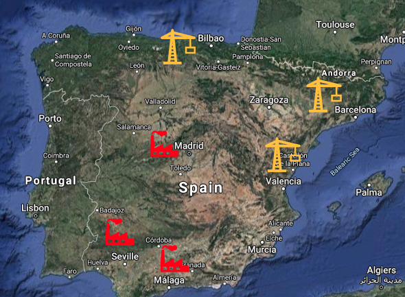

```python
df_data = pd.DataFrame({ 'origen':['Barcelona'   , 'Barcelona'   , 'Barcelona'   ,'Valencia'   ,'Valencia'   ,'Valencia'   ,'Bilbao'    ,'Bilbao'    ,'Bilbao'   ],
                         'destino':['Madrid' ,'Sevilla' ,'Malaga'  ,'Madrid' ,'Sevilla'  ,'Malaga' ,'Madrid' ,'Sevilla'  ,'Malaga'  ],
                         'coste':[0.682,0.995 ,0.976 ,0.562, 0.756, 0.720, 0.402 ,0.861 ,0.922],
                         'stock':[174  ,174   ,174   ,36  ,36  ,36  ,57   ,57   ,57  ] ,
                         'demanda':[54  ,45   ,23   ,54  ,45  ,23  ,54   ,45   ,23  ],
                   })

df_data
```

|  | origen | destino | coste | stock | demanda |
| --- | --- | --- | --- | --- | --- |
| 0 | Barcelona | Madrid | 0.682 | 174 | 54 |
| 1 | Barcelona | Sevilla | 0.995 | 174 | 45 |
| 2 | Barcelona | Malaga | 0.976 | 174 | 23 |
| 3 | Valencia | Madrid | 0.562 | 36 | 54 |
| 4 | Valencia | Sevilla | 0.756 | 36 | 45 |
| 5 | Valencia | Malaga | 0.720 | 36 | 23 |
| 6 | Bilbao | Madrid | 0.402 | 57 | 54 |
| 7 | Bilbao | Sevilla | 0.861 | 57 | 45 |
| 8 | Bilbao | Malaga | 0.922 | 57 | 23 |

#### Visualizar datos entrada

##### Stock y demanda

```python
# Plot stocks
df_aux = df_data[['origen','stock']].drop_duplicates()

fig = px.bar(df_aux,
             x="origen",
             y="stock",
             title="Stocks")
fig.update_yaxes(title_text='Stocks (ud)')
fig.update_xaxes(title_text='Origenes')
fig.update_layout(font=dict(family="Courier New, monospace", size=18, color="#7f7f7f"))
fig.show()

# Plot demanda
df_aux = df_data[['destino','demanda']].drop_duplicates()

fig = px.bar(df_aux,
             x="destino",
             y="demanda",
             title="Demanda")
fig.update_yaxes(title_text='Demanda (ud)')
fig.update_xaxes(title_text='Destinos')
fig.update_layout(font=dict(family="Courier New, monospace", size=18, color="#7f7f7f"))
fig.show()
```

[interactive chart not shown]

##### Costes

```python
df_aux = df_data[['origen','destino','coste']].drop_duplicates().pivot(index='destino',values='coste', columns='origen').fillna(0)

fig = go.Figure(data=go.Heatmap(
                   z=df_aux.values,
                   y=df_data['origen'].unique().tolist(),
                   x=df_data['destino'].unique().tolist(),
                   hoverongaps = False))
fig.update_yaxes(title_text='origen')
fig.update_xaxes(title_text='destino')
fig.update_layout(title='Costes de envio')
fig.update_layout(font=dict(family="Courier New, monospace", size=18, color="#7f7f7f"))
fig.show()
```

[interactive chart not shown]

### Guardar datos en formato adecuado

```python
df_data[['origen', 'stock']].drop_duplicates()['origen'].to_csv('data/set_origen.tab', index=False, sep=' ')
df_data[['destino', 'demanda']].drop_duplicates()['destino'].to_csv('data/set_destino.tab', index=False, sep=' ')

df_data[['origen', 'stock']].drop_duplicates().to_csv('data/param_stock.tab', index=False, sep=' ')
df_data[['destino', 'demanda']].drop_duplicates().to_csv('data/param_demand.tab', index=False, sep=' ')

df_data[['origen', 'destino', 'coste']].to_csv('data/param_coste.tab', index=False, sep=' ')
```

### Crear instancia de datos

```python
data = pyo.DataPortal(model=model)

data.load(filename='data/set_origen.tab', set="origen", format="set")
data.load(filename='data/set_destino.tab', set="destino", format="set")

data.load(filename='data/param_stock.tab', param=model.stock)
data.load(filename='data/param_demand.tab', param=model.demanda)

data.load(filename='data/param_coste.tab', param=model.coste)
```

### Instanciar modelo con datos

```python
instance = model.create_instance(data)

### comprobar instancia creada
#instance.pprint()
```

### Definir Solver

```python
# Definimos Solver
from pyomo.opt import SolverFactory
opt = SolverFactory("glpk")
```

### Resolver problema de optimización

Al resolver el modelo se dará una de las siguientes situaciones:

- **El problema es no factible**: No existe ninguna solución que cumpla simultáneamente todas las restricciones
- **El problema es no acotado**: Funcion no convexa (z=infinito)
- **Tiene una única solución**: El problema tiene solución factible, es acotado y existe un óptimo y es único
- **Tiene múltiples soluciones**: El problema tiene solución factible, es acotado y existen varios óptimos. Todos los óptimos serán equivalentes, esto es, proporcionan el mismo valor de z

```python
results = opt.solve(instance, tee=False) # tee is a option to plot process

#send results to stdout
#results.write()
#!cat results.yml

print('--- Problem Results ---')
print(results.Problem())
print('--- Solver Results ---')
print(results.Solver())

print('--- Restriccion Stock ---')
print(instance.const_stock.display())
print('--- Restriccion Demanda ---')
print(instance.const_demand.display())
print('--- Coste Total ---')
print(instance.total_cost.display())
```

```
--- Problem Results ---

Name: unknown
Lower bound: 79.534
Upper bound: 79.534
Number of objectives: 1
Number of constraints: 7
Number of variables: 10
Number of nonzeros: 19
Sense: minimize

--- Solver Results ---

Status: ok
Termination condition: optimal
Statistics:
  Branch and bound:
    Number of bounded subproblems: 0
    Number of created subproblems: 0
Error rc: 0
Time: 0.022034168243408203

--- Restriccion Stock ---
const_stock : Size=3
    Key       : Lower : Body : Upper
    Barcelona :  None : 29.0 : 174.0
       Bilbao :  None : 57.0 :  57.0
     Valencia :  None : 36.0 :  36.0
None
--- Restriccion Demanda ---
const_demand : Size=3
    Key     : Lower : Body : Upper
     Madrid :  54.0 : 54.0 :  54.0
     Malaga :  23.0 : 23.0 :  23.0
    Sevilla :  45.0 : 45.0 :  45.0
None
--- Coste Total ---
total_cost : Size=1, Index=None, Active=True
    Key  : Active : Value
    None :   True : 79.53399999999999
None
```

### Explorar Resultados

```python
def dl_ia_opt_get_results(instance):
    """ Funtion to check resutls
        :param results: optimization resutls
        :return: dataframe with resutls
    """

    import pandas as pd
    try:
        origen = []
        destino = []
        cantidad = []
        for i in instance.origen:
            for j in instance.destino:
                origen.append(i)
                destino.append(j)
                cantidad.append(instance.x[(i, j)].value)

        df_out = pd.DataFrame({'origen':origen, 'destino':destino, 'cantidad':cantidad})
        df_out['origen'] = df_out['origen'].astype(str)
        df_out['destino'] = df_out['destino'].astype(str)
        df_out['cantidad'] = df_out['cantidad'].astype(int)


        return df_out


    except Exception as exception_msg:
        print('(!) Error in dl_ia_opt_get_results: {}'.format(str(exception_msg)))
```

```python
df_results = dl_ia_opt_get_results(instance)
print('Coste total: {} euros'.format(instance.total_cost.expr()))
print('Tiempo de ejecución: {} s'.format(round(results.Solver.Time,4)))
print('Suministro: {} lotes'.format(df_results['cantidad'].sum()))
df_results
```

```
Coste total: 79.53399999999999 euros
Tiempo de ejecución: 0.022 s
Suministro: 122 lotes
```

|  | origen | destino | cantidad |
| --- | --- | --- | --- |
| 0 | Barcelona | Madrid | 0 |
| 1 | Barcelona | Sevilla | 29 |
| 2 | Barcelona | Malaga | 0 |
| 3 | Valencia | Madrid | 0 |
| 4 | Valencia | Sevilla | 13 |
| 5 | Valencia | Malaga | 23 |
| 6 | Bilbao | Madrid | 54 |
| 7 | Bilbao | Sevilla | 3 |
| 8 | Bilbao | Malaga | 0 |

```python
df_aux = df_results[['origen','destino','cantidad']].drop_duplicates().pivot(index='destino',values='cantidad', columns='origen').fillna(0)

fig = go.Figure(data=go.Heatmap(
                   z=df_aux.values,
                   y=df_results['origen'].unique().tolist(),
                   x=df_results['destino'].unique().tolist(),
                   hoverongaps = False))
fig.update_yaxes(title_text='origen')
fig.update_xaxes(title_text='destino')
fig.update_layout(title='Cantidad de producto')
fig.update_layout(font=dict(family="Courier New, monospace", size=18, color="#7f7f7f"))
fig.show()
```

[interactive chart not shown]

### Mejoras

- **¿Y si existe stock minimo?**
  - *Restriccion stock minimo*
- **¿Y si hay mas de un producto?**
  - *costes por origen, destino y producto*
- **¿Y si hay diferentes modos de transporte?**
  - *costes origen, destino, modo*
- **¿Y si los productos se pueden agrupar?**
  - *Añadir caracterisitcas del producto: peso, volumen, precio, reglas de agrupamiento*
- **¿Y si no hay suficiente stock?**
  - *Introducir preferencias en destinos*
- **¿Y si hay productos alternativos?**
  - *Introducir preferencia por original, suministrar alternativo en caso de no stock*
- **¿Y si es multiperiodo?**
  - *Programación dinámica, introducir demanda y stock por horizonte temporal*
- **¿Y que pasa si hay nodos intermedios?**
  - *Definir mediante expresiones ecuaciones auxiliares*

# Proximamente

- Optimización multi-objetivo
- Comparativa de tiempos de ejecuión y esfuerzo computacional
- Mas ejemplos con aplicación a sensores, transporte, flujos, cartera de valores, etc..

# Referencias

- [pyomo repository](https://github.com/Pyomo)
- [Pyomo Modelling Components](https://pyomo.readthedocs.io/en/stable/pyomo_modeling_components/index.html)
- [Pyomo Documentation](https://pyomo.readthedocs.io/en/latest/)
- [Expressions pyomo](https://pyomo.readthedocs.io/en/stable/pyomo_modeling_components/Expressions.html)
- [Gallery](https://github.com/Pyomo/PyomoGallery/wiki)
- [Accessing Pyomo variable values and objective function value](http://hselab.org/pyomo-get-variable-values.html)
- [latex symbols](https://oeis.org/wiki/List_of_LaTeX_mathematical_symbols)
- [latex math](https://www.overleaf.com/learn/latex/Matrices)
- [Gams solvers](https://www.gams.com/latest/docs/S_MAIN.html)
- [IBM optimization](https://www.ibm.com/analytics/optimization-solver)
- [Solvers comparative](https://www.researchgate.net/publication/314750497_A_Comparative_Analysis_of_Optimization_Solvers)
- [More about optimization solvers](https://cran.r-project.org/web/views/Optimization.html)
- [Book optimization UCLM](http://www.dia.fi.upm.es/~jafernan/teaching/operational-research/LibroCompleto.pdf)
- [Pareto Frontier Method](https://www.researchgate.net/publication/265600679_On_Epsilon-Constraint_Based_Methods_for_the_Generation_of_Pareto_Frontiers)
- [(Udemy) Complete Pyomo Bootcamp: Python Optimization Beginners](https://www.udemy.com/share/103zuUAEAYdlhWTXQB/)